# Recurrent gene hotspots

In this notebook we will use look at recurrence and hotspots in OpenPBTA snv

Recurrence:

- Filter Variant_Classification =‘Missense_Mutation|Splice_Region|In_Frame_Del|Frame_Shift_Del|Splice_Site|Splice_Region|Nonsense_Mutation|Nonstop_Mutation|In_Frame_Ins|Frameshift_Ins’,
- Filter IMPACT =‘HIGH|MODERATE’
- Filter given gene list from fusion_filtering/reference/genelistreference.txt
- Count reoccurence per Hugo_Symbol+Protein_position+DOMAINS+type

Hotspots: -Protein_position overlaps MSKCC cancer hotspot database

## Setup

| descriptors | n |
| --- | --- |
| Initial CNS Tumor | 633 |
| Initial CNS Tumor, Progressive | 26 |
| Initial CNS Tumor, Progressive Disease Post-Mortem | 3 |
| Initial CNS Tumor, Progressive, Progressive Disease Post-Mortem | 1 |
| Initial CNS Tumor, Progressive, Recurrence | 3 |
| Initial CNS Tumor, Recurrence | 15 |
| Initial CNS Tumor, Second Malignancy | 5 |
| Progressive | 78 |
| Progressive, Recurrence | 6 |
| Recurrence | 34 |
| Recurrence, Second Malignancy | 1 |
| Second Malignancy | 7 |
| Unavailable | 1 |

We have instances of multiple samples per Kids_First_Participant_ID so will use the independent selected sample list from `independent-samples` module.

## Select independent samples

```r
# Select independent sample set
# Include primary tumors when available, if not select other tumor_descriptor types
independentsamples <- read_tsv(file.path(
  root_dir,
  "analyses",
  "independent-samples",
  "results",
  "independent-specimens.wgswxs.primary-plus.tsv"))  %>%
  pull(Kids_First_Biospecimen_ID)
```

## Cancer hotspot files

```r
# Cancer database
hotspot_database_2017_snv <- readxl::read_xls(mskcc_cancer_hotspot_file,sheet = 1)
hotspot_database_2017_indel <- readxl::read_xls(mskcc_cancer_hotspot_file,sheet = 2)

hotspot_database <- bind_rows( hotspot_database_2017_snv, hotspot_database_2017_indel) %>%
  dplyr::select("Amino_Acid_Position","Hugo_Symbol") %>%
  dplyr::mutate(hotspot_database="MSKCC") %>%
  unique()
```

## Get combined and filtered maf calls from strelka,mutect, vardict, lancet

```r
combined_maf_subsets<- readRDS( file.path("results","combined_maf_subsets.RDS"))
```

## Gene table for filtering

```r
# generic cancer genes  of interest
gene_table <- read_tsv(file.path("..",
                                 "fusion_filtering",
                                 "references",
                                 "genelistreference.txt"))%>%
  dplyr::rename(Hugo_Symbol=Gene_Symbol) %>%
  dplyr::select(Hugo_Symbol,type)
# genes of interest for brain tumors
brain_goi <- read_tsv("input/brain-goi-list-new.txt",col_names = "Hugo_Symbol") %>%
    dplyr::mutate(type="brain-goi")
gene_table <- bind_rows(gene_table,
            brain_goi) %>%
  group_by(Hugo_Symbol) %>%
  summarise(type=toString(unique(type)))
```

## Summarise calls per site in Tumor_Sample_Barcode for brain GOI only

```r
summarise_sites <- combined_maf_subsets %>%
  # get gene annotation from gene reference
    left_join(gene_table,by="Hugo_Symbol") %>%
  # check if gnomad_AF is > 0.001
  mutate(gnomad_AF_common = gnomAD_AF>0.001 & !is.na(gnomAD_AF)) %>%
  group_by(Chromosome,Start_Position,End_Position,
           Amino_Acid_Position,Hugo_Symbol,
           Tumor_Sample_Barcode) %>%
  # summarise the following columns per genomic site
  summarise( type = toString(type),
            gnomad_AF_common = any(gnomad_AF_common),
            VAF = mean(VAF),
            dbSNP_RS = toString(unique(dbSNP_RS)),
            Variant_Classification=toString(unique(Variant_Classification)),
            Reference_Allele=toString(unique(Reference_Allele)),
            Tumor_Seq_Allele2=toString(unique(Tumor_Seq_Allele2)),
            HGVSp_Short=toString(unique(HGVSp_Short)),
            Variant_Type=toString(unique(Variant_Type))) %>%
  # annotate if amino acid position is available in MSKCC hotspot
    left_join(hotspot_database,by=c("Amino_Acid_Position","Hugo_Symbol")) %>%
  # annotate if gene is in Cosmic Census gene
  mutate(hotspot_database = case_when(
    grepl("Cosmic",type) & !is.na(hotspot_database) ~ paste0(hotspot_database,",Cosmic"),
    grepl("Cosmic",type) & is.na(hotspot_database) ~ "Cosmic",
    TRUE ~ hotspot_database
  )) %>%
  # filter only brain-goi
  dplyr::filter( grepl("brain-goi",type)) %>%
  # select independent samples only
  dplyr::filter(Tumor_Sample_Barcode %in% independentsamples)
```

## Recurrence in genes part of brain-goi from filtered snv calls

```r
calls_recurrence <- summarise_sites %>%
    count(Chromosome,
          Start_Position,
          End_Position,
          Amino_Acid_Position,
          Hugo_Symbol,type,
          gnomad_AF_common,
          hotspot_database,
          Variant_Classification,
          dbSNP_RS,
          Reference_Allele,
          Tumor_Seq_Allele2,
          HGVSp_Short,
          Variant_Type,
          sort = TRUE) %>%
  dplyr::filter(n>2)
```

## Plot VAF separating by present or absent in MSKCC database

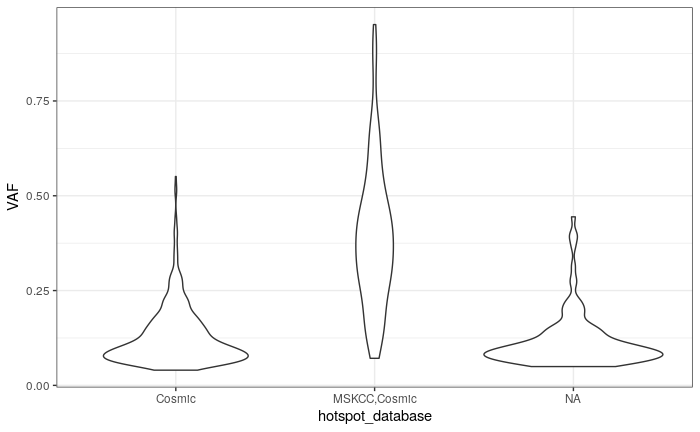

```r
calls_recurrence %>%
  left_join(summarise_sites) %>%
  ggplot(aes(x=hotspot_database,y=VAF))+ geom_violin()+theme_bw()
```

## Sites not part of MSKCC cancer hotspots/Cosmic

```r
# maftools needs a maf file to be read via read.maf
# so we are using the exact sites that don't overlap
# MSKCC cancer database nor are Cosmic census gene lists
uniqhits <- calls_recurrence %>%
  left_join(combined_maf_subsets) %>%
  dplyr::filter(is.na(hotspot_database) )
uniqhitsGenes<- uniqhits %>%
  pull(Hugo_Symbol) %>%
  unique()

# save as maf for maftools functions
uniqhits %>%
  dplyr::select(-caller) %>%
  group_by(Chromosome,Start_Position,End_Position,
           Amino_Acid_Position,Hugo_Symbol,
           Tumor_Sample_Barcode,
           Variant_Type,
           Reference_Allele,
           Tumor_Seq_Allele2,
           HGVSp_Short,
           Variant_Classification) %>%
  # doing a mean so that caller specific VAF
  # calculations doesn't unique rows
  summarise(VAF = mean(VAF)) %>%
  write_tsv("results/uniqhits.maf")
```

### Upset plots for the unique hits

SNP: Single nucleotide polymorphism – a substitution in one nucleotide DNP: Double nucleotide polymorphism – a substitution in two consecutive nucleotides TNP: Triple nucleotide polymorphism – a substitution in three consecutive nucleotides ONP: Oligo-nucleotide polymorphism – a substitution in more than three consecutive nucleotides

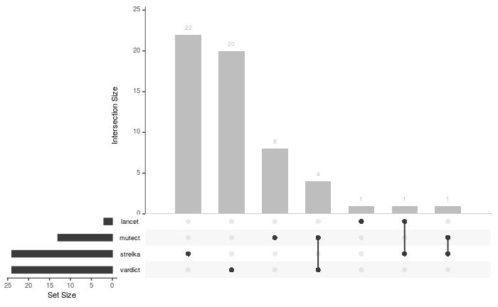

```r
source(file.path("utils","getUpset.R"))
getUpset(uniqhits,c("SNP","DNP","TNP","ONP"))
```

Interestingly a lot of the uniq hits are supported by strelka only, followed by vardict.

INS: Insertion – the addition of nucleotides DEL: Deletion – the removal of nucleotides

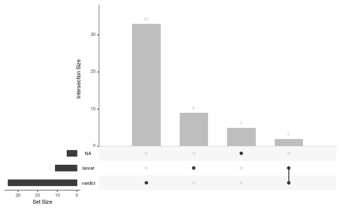

```r
getUpset(uniqhits,c("INS","DEL"))
```

Vardict and Lancet again uniquely support a lot of novel indels.

## Summary plots

```r
uniqhitsmaf <- maftools::read.maf("results/uniqhits.maf")
```

```
-Reading
-Validating
-Summarizing
-Processing clinical data
--Missing clinical data
-Finished in 0.057s elapsed (0.050s cpu)
```

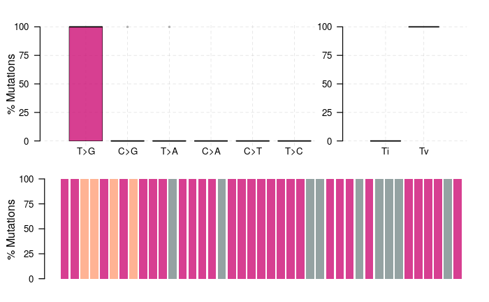

```r
uniq.titv = titv(maf = uniqhitsmaf, plot = FALSE, useSyn = TRUE)
#plot titv summary
plotTiTv(res = uniq.titv)
```

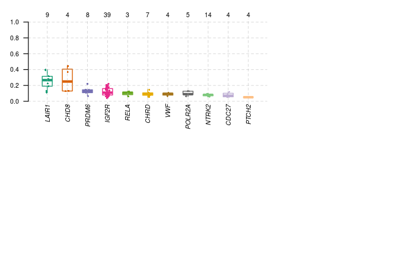

```r
# Here the VAF column is unique to each Tumor_Sample_Barcode
# which we didn't considere as a column to count recurrence on.
# So the values here maybe difference compared to what we find
# in calls_recurrence
plotVaf(uniqhitsmaf,vafCol = "VAF",genes = uniqhitsGenes)
```

```r
NA
NA
```

## Genes with multiple hits in recurrence

```r
multihitsGenes <- calls_recurrence %>%
  group_by(Hugo_Symbol) %>%
  tally() %>%
  filter(n>5) %>%
  pull(Hugo_Symbol)

# maftools needs a maf file to be read via read.maf
multihits <- combined_maf_subsets %>%
  # selecting sites in multiHits genes from filtered maf
  dplyr::filter(Hugo_Symbol %in% multihitsGenes) %>%
  # doing an inner join with recurrent sites
  # to visualize just the VAFs of these sites
  inner_join(calls_recurrence)
multihits %>%
  dplyr::select(-caller) %>%
  group_by(Chromosome,Start_Position,End_Position,
           Amino_Acid_Position,Hugo_Symbol,
           Tumor_Sample_Barcode,
           Variant_Type,
           Reference_Allele,
           Tumor_Seq_Allele2,
           HGVSp_Short,
           Variant_Classification) %>%
  # doing a mean so that caller specific VAF
  # calculations doesn't unique rows
  summarise(VAF = mean(VAF)) %>%
  write_tsv("results/multihits.maf")
```

SNP: Single nucleotide polymorphism – a substitution in one nucleotide DNP: Double nucleotide polymorphism – a substitution in two consecutive nucleotides TNP: Triple nucleotide polymorphism – a substitution in three consecutive nucleotides ONP: Oligo-nucleotide polymorphism – a substitution in more than three consecutive nucleotides

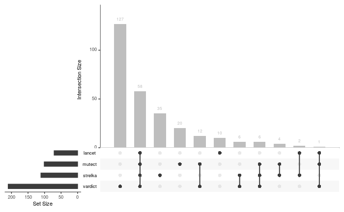

```r
getUpset(multihits,c("SNP","DNP","TNP","ONP"))
```

INS: Insertion – the addition of nucleotides DEL: Deletion – the removal of nucleotides

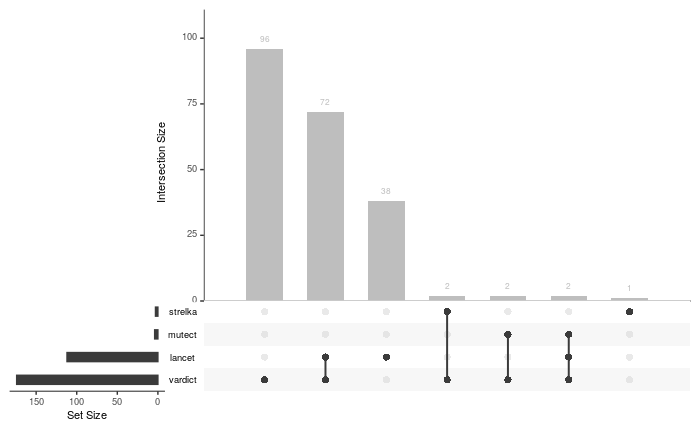

```r
getUpset(multihits,c("INS","DEL"))
```

Vardict and Lancet uniquely support a lot of the multihit sites

### Plot lollipops

```r
multihitsmaf <- maftools::read.maf("results/multihits.maf")
```

```
-Reading
-Validating
-Summarizing
-Processing clinical data
--Missing clinical data
-Finished in 0.072s elapsed (0.060s cpu)
```

```r
pdf("results/multihits.pdf",width = 15,height = 8)
lapply(multihitsGenes,function(x){
maftools::lollipopPlot(multihitsmaf,gene = x ,AACol = "HGVSp_Short")})
```

| HGNC | refseq.ID | protein.ID | aa.length |
| --- | --- | --- | --- |
| CTNNB1 | NM_001098210 | NP_001091680 | 781 |
| CTNNB1 | NM_001904 | NP_001895 | 781 |
| CTNNB1 | NM_001098209 | NP_001091679 | 781 |

| HGNC | refseq.ID | protein.ID | aa.length |
| --- | --- | --- | --- |
| DDX3X | NM_001356 | NP_001347 | 662 |
| DDX3X | NM_001193416 | NP_001180345 | 661 |
| DDX3X | NM_001193417 | NP_001180346 | 646 |

| HGNC | refseq.ID | protein.ID | aa.length |
| --- | --- | --- | --- |
| TP53 | NM_000546 | NP_000537 | 393 |
| TP53 | NM_001126112 | NP_001119584 | 393 |
| TP53 | NM_001126118 | NP_001119590 | 354 |
| TP53 | NM_001126115 | NP_001119587 | 261 |
| TP53 | NM_001126113 | NP_001119585 | 346 |
| TP53 | NM_001126117 | NP_001119589 | 214 |
| TP53 | NM_001126114 | NP_001119586 | 341 |
| TP53 | NM_001126116 | NP_001119588 | 209 |

```r
dev.off()
```

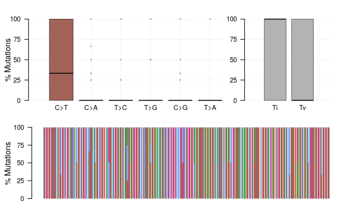

```r
multi.titv = titv(maf = multihitsmaf, plot = FALSE, useSyn = TRUE)
#plot titv summary
plotTiTv(res = multi.titv)
```

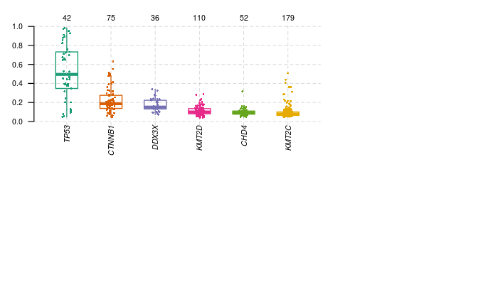

```r
# Here the VAF column is unique to each Tumor_Sample_Barcode
# which we didn't consider as a column on which to count recurrence.
# So the values here maybe difference compared to what we find
# in calls_recurrence
plotVaf(multihitsmaf,vafCol = "VAF")
```

## Save

```r
calls_recurrence %>% write_tsv(file.path(results_dir,"snv_recurrence.tsv"))
```